# Regression Practice

Adam Johnson

12/13/2021

## Mutiple Linear Regression Practice

This Markdown file will show the building of a multiple linear regression model of the real estate data set located here: https://www.kaggle.com/quantbruce/real-estate-price-prediction/code

The goal of the model will be to predict the house_price_of_unit_area.

```r
# Load the dataset into realestate data frame
realestate <- read.csv("Realestate.csv")
```

## Initial Analysis

The first step of my analysis is to become comfortable with and knowledgeable of the data. The below code displays the beginning rows of the data frame. The second line displays summary statistics of all of the columns of the data frame.

```r
# View structure of the Data
head(realestate)
```

```
##   No transaction_date house_age distance_to_station number_of_stores latitude
## 1  1         2012.917      32.0            84.87882               10 24.98298
## 2  2         2012.917      19.5           306.59470                9 24.98034
## 3  3         2013.583      13.3           561.98450                5 24.98746
## 4  4         2013.500      13.3           561.98450                5 24.98746
## 5  5         2012.833       5.0           390.56840                5 24.97937
## 6  6         2012.667       7.1          2175.03000                3 24.96305
##   longitude house_price_of_unit_area
## 1  121.5402                     37.9
## 2  121.5395                     42.2
## 3  121.5439                     47.3
## 4  121.5439                     54.8
## 5  121.5425                     43.1
## 6  121.5125                     32.1
```

```r
#View Summary of Data
summary(realestate)
```

```
##        No        transaction_date   house_age      distance_to_station
##  Min.   :  1.0   Min.   :2013     Min.   : 0.000   Min.   :  23.38
##  1st Qu.:104.2   1st Qu.:2013     1st Qu.: 9.025   1st Qu.: 289.32
##  Median :207.5   Median :2013     Median :16.100   Median : 492.23
##  Mean   :207.5   Mean   :2013     Mean   :17.713   Mean   :1083.89
##  3rd Qu.:310.8   3rd Qu.:2013     3rd Qu.:28.150   3rd Qu.:1454.28
##  Max.   :414.0   Max.   :2014     Max.   :43.800   Max.   :6488.02
##  number_of_stores    latitude       longitude     house_price_of_unit_area
##  Min.   : 0.000   Min.   :24.93   Min.   :121.5   Min.   :  7.60
##  1st Qu.: 1.000   1st Qu.:24.96   1st Qu.:121.5   1st Qu.: 27.70
##  Median : 4.000   Median :24.97   Median :121.5   Median : 38.45
##  Mean   : 4.094   Mean   :24.97   Mean   :121.5   Mean   : 37.98
##  3rd Qu.: 6.000   3rd Qu.:24.98   3rd Qu.:121.5   3rd Qu.: 46.60
##  Max.   :10.000   Max.   :25.01   Max.   :121.6   Max.   :117.50
```

## Checking for Linearity

In order to perform a regression analysis, the relationship between the dependent variable and the independent variables must be linear. In order to check this, I created multiple scatter plots between all of the different variables.

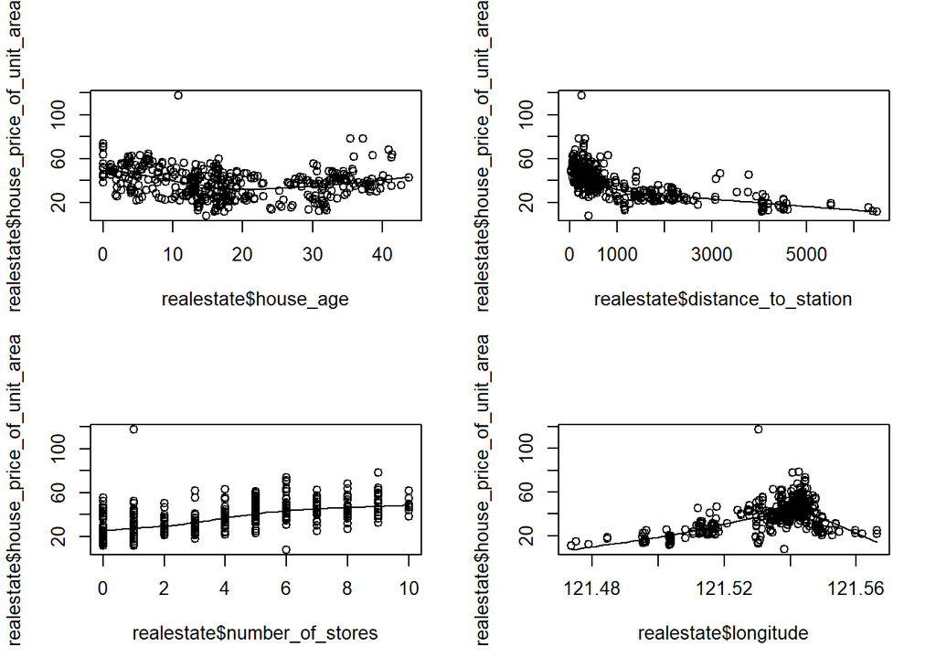

```r
# Creates scatter plot of all of the variables to check for linearity.
# Appears that the relationship is linear with house age, distance to station, and number of stores
par(mfrow = c(2,2))
scatter.smooth(x = realestate$house_age, y = realestate$house_price_of_unit_area)
scatter.smooth(x = realestate$distance_to_station, y = realestate$house_price_of_unit_area)
scatter.smooth(x = realestate$number_of_stores, y = realestate$house_price_of_unit_area)
scatter.smooth(x = realestate$longitude, y = realestate$house_price_of_unit_area)
```

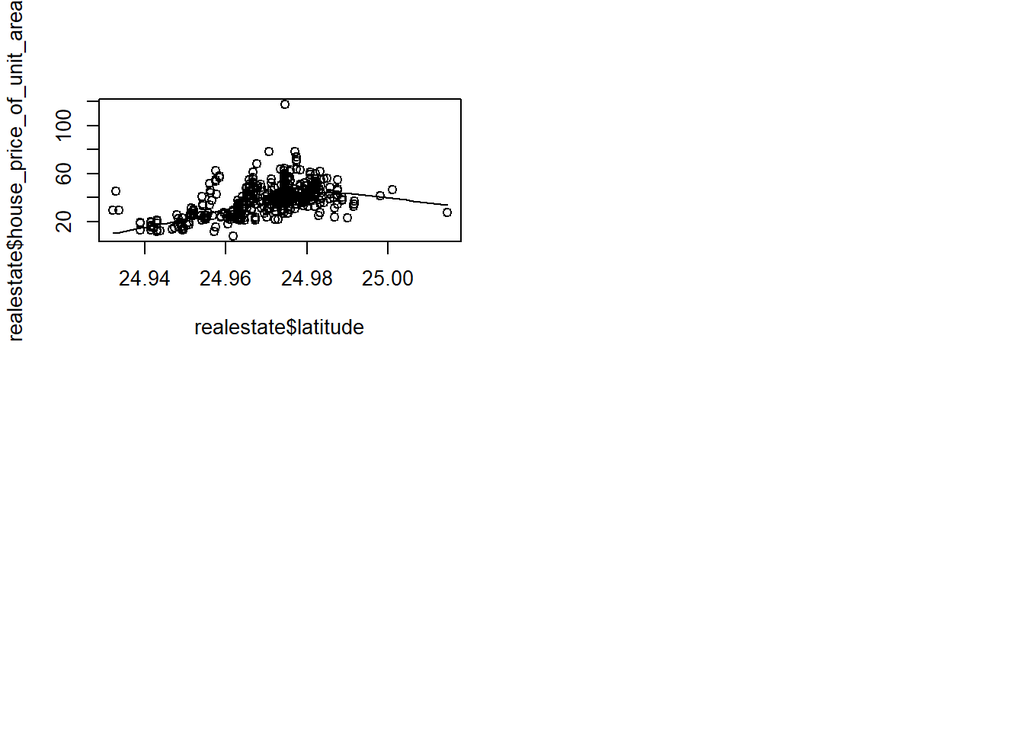

```r
scatter.smooth(x = realestate$latitude, y = realestate$house_price_of_unit_area)
```

## Checking for Outliers

Next, I want to check all of the variables for any outliers which may skew the data. To do this, I created box plots of all of the variables.

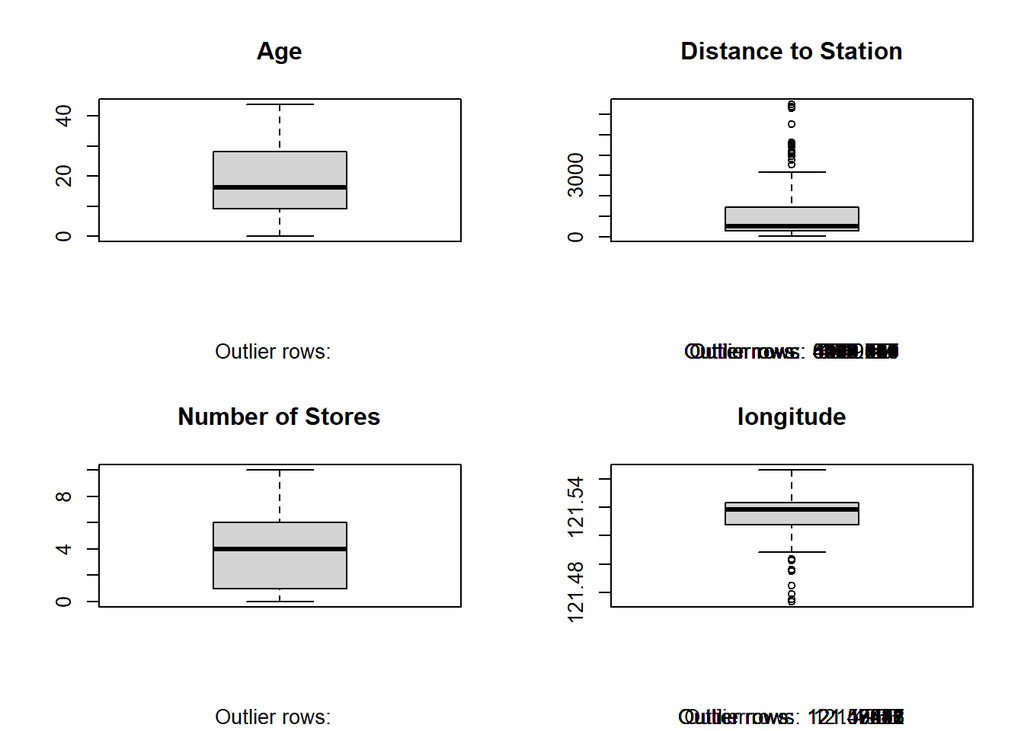

```r
# Box Plots to check for Outliers
# Distance to Station has a lot of Outliers that may need to be addressed
par(mfrow = c(2,2))
boxplot(realestate$house_age, main="Age", sub=paste("Outlier rows: ", boxplot.stats(realestate$house_age)$out))
boxplot(realestate$distance_to_station, main="Distance to Station", sub=paste("Outlier rows: ", boxplot.stats(realestate$distance_to_station)$out))
boxplot(realestate$number_of_stores, main="Number of Stores", sub=paste("Outlier rows: ", boxplot.stats(realestate$number_of_stores)$out))
boxplot(realestate$longitude, main="longitude", sub=paste("Outlier rows: ", boxplot.stats(realestate$longitude)$out))
```

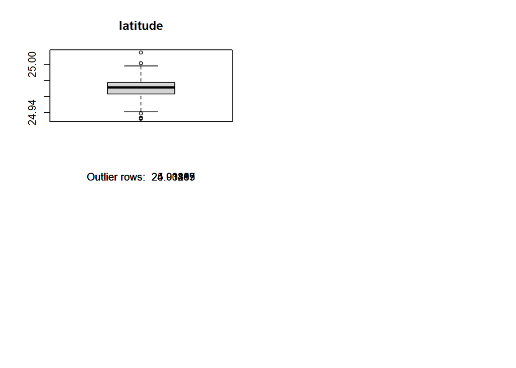

```r
boxplot(realestate$latitude, main="latitude", sub=paste("Outlier rows: ", boxplot.stats(realestate$latitude)$out))
```

From the box plots it is clear that the variable with the majority of outliers is distance_to_station. It is good to note this, as the larger number of outliers may cause issues in the model.

## Correlation of Variables

Next, I wanted to check which variables were strongly correlated with each other. I did this to assist with choosing the predictor variables for the linear model I will be constructing.

```r
# Checking for Correlations of Variables
cor(realestate)
```

```
##                                   No transaction_date   house_age
## No                        1.00000000     -0.048657949 -0.03280811
## transaction_date         -0.04865795      1.000000000  0.01754877
## house_age                -0.03280811      0.017548767  1.00000000
## distance_to_station      -0.01357349      0.060879953  0.02562205
## number_of_stores         -0.01269895      0.009635445  0.04959251
## latitude                 -0.01010966      0.035057756  0.05441990
## longitude                -0.01105928     -0.041081778 -0.04852005
## house_price_of_unit_area -0.02858717      0.087490606 -0.21056705
##                          distance_to_station number_of_stores    latitude
## No                               -0.01357349     -0.012698946 -0.01010966
## transaction_date                  0.06087995      0.009635445  0.03505776
## house_age                         0.02562205      0.049592513  0.05441990
## distance_to_station               1.00000000     -0.602519145 -0.59106657
## number_of_stores                 -0.60251914      1.000000000  0.44414331
## latitude                         -0.59106657      0.444143306  1.00000000
## longitude                        -0.80631677      0.449099007  0.41292394
## house_price_of_unit_area         -0.67361286      0.571004911  0.54630665
##                            longitude house_price_of_unit_area
## No                       -0.01105928              -0.02858717
## transaction_date         -0.04108178               0.08749061
## house_age                -0.04852005              -0.21056705
## distance_to_station      -0.80631677              -0.67361286
## number_of_stores          0.44909901               0.57100491
## latitude                  0.41292394               0.54630665
## longitude                 1.00000000               0.52328651
## house_price_of_unit_area  0.52328651               1.00000000
```

## Building the Model

Now that the assumptions have been met, it is time to construct our first model. This first attempt includes all of the predictor variables to start.

Before actually constructing the model, I am going to divide the data into Training and Testing subsets for purposes of testing the model.

```r
# Divides data into two sets.  Training Data = 80% and Testing = 20%
set.seed(100)  # setting seed to reproduce results of random sampling
trainingRow <- sample(1:nrow(realestate), 0.8*nrow(realestate))  # row indices for training data
trainingData <- realestate[trainingRow, ]  # model training data
testData  <- realestate[-trainingRow, ]
```

Now that the data has been partitioned, it is time to begin building the model on the training data.

```r
# Creates the first model.  All variables included
model1 <- lm(house_price_of_unit_area ~ house_age + distance_to_station + number_of_stores + latitude +
               longitude + transaction_date, data = trainingData)
summary(model1)
```

```
##
## Call:
## lm(formula = house_price_of_unit_area ~ house_age + distance_to_station +
##     number_of_stores + latitude + longitude + transaction_date,
##     data = trainingData)
##
## Residuals:
##     Min      1Q  Median      3Q     Max
## -35.921  -5.398  -1.227   4.393  74.465
##
## Coefficients:
##                       Estimate Std. Error t value Pr(>|t|)
## (Intercept)         -1.499e+04  7.611e+03  -1.969  0.04979 *
## house_age           -2.562e-01  4.434e-02  -5.777 1.79e-08 ***
## distance_to_station -5.013e-03  8.188e-04  -6.123 2.66e-09 ***
## number_of_stores     1.014e+00  2.239e-01   4.529 8.34e-06 ***
## latitude             2.118e+02  4.988e+01   4.246 2.85e-05 ***
## longitude           -1.655e+01  5.396e+01  -0.307  0.75918
## transaction_date     5.839e+00  1.806e+00   3.233  0.00135 **
## ---
## Signif. codes:  0 '***' 0.001 '**' 0.01 '*' 0.05 '.' 0.1 ' ' 1
##
## Residual standard error: 9.184 on 324 degrees of freedom
## Multiple R-squared:  0.5615, Adjusted R-squared:  0.5534
## F-statistic: 69.14 on 6 and 324 DF,  p-value: < 2.2e-16
```

```r
# Removed Longitude variable from the model
model2 <- lm(house_price_of_unit_area ~ house_age + distance_to_station + number_of_stores + latitude
             + transaction_date, data = trainingData)
summary(model2)
```

```
##
## Call:
## lm(formula = house_price_of_unit_area ~ house_age + distance_to_station +
##     number_of_stores + latitude + transaction_date, data = trainingData)
##
## Residuals:
##     Min      1Q  Median      3Q     Max
## -35.869  -5.323  -1.336   4.314  74.678
##
## Coefficients:
##                       Estimate Std. Error t value Pr(>|t|)
## (Intercept)         -1.703e+04  3.708e+03  -4.592 6.29e-06 ***
## house_age           -2.555e-01  4.423e-02  -5.777 1.78e-08 ***
## distance_to_station -4.837e-03  5.840e-04  -8.283 3.18e-15 ***
## number_of_stores     1.020e+00  2.229e-01   4.576 6.74e-06 ***
## latitude             2.135e+02  4.950e+01   4.313 2.14e-05 ***
## transaction_date     5.831e+00  1.803e+00   3.233  0.00135 **
## ---
## Signif. codes:  0 '***' 0.001 '**' 0.01 '*' 0.05 '.' 0.1 ' ' 1
##
## Residual standard error: 9.172 on 325 degrees of freedom
## Multiple R-squared:  0.5614, Adjusted R-squared:  0.5546
## F-statistic: 83.18 on 5 and 325 DF,  p-value: < 2.2e-16
```

The second model shows that all of the coefficients are significant, which is an improvement over the first edition of the model. The Adj-R^2 is also slightly higher, and standard error is lower. The F-statistic is also higher than the previous model, which shows that the model is fitting the data better than it was before.

## Model Validation

Now that we have selected a model, we must check to see that the model meets all the assumptions required of a linear regression. These assumptions are linearity (Check above), Normality of the residuals, no Multicollinearity and no heteroskedasticity. To check these assumptions, I will be using the “lindia” package to graph all of the relevant charts at once.

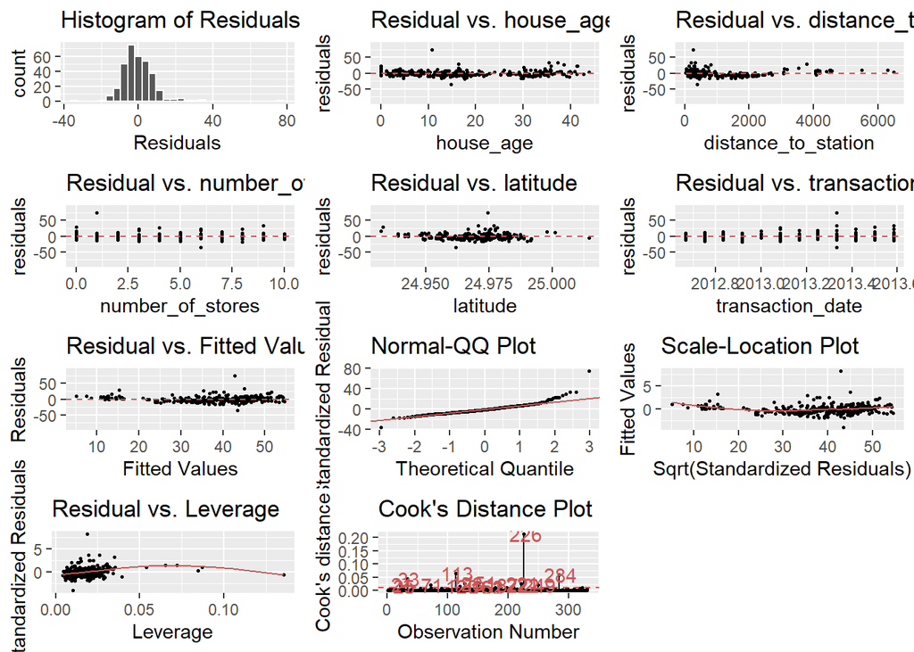

```r
library(lindia)
lindia::gg_diagnose(model2)
```

```r
# Check for multicollinearity
library("caret")
car::vif(model2)
```

```
##           house_age distance_to_station    number_of_stores            latitude
##            1.027031            2.035765            1.700911            1.525392
##    transaction_date
##            1.029007
```

This function makes it very easy to see that there is no Multicollinearity in this model, as all of the values returned from the VIF function are relatively low.

Since there is no Multicollinearity, we can now test to see if there is any sign of autocorrelations. Autocorrelations are when the resiudals are not independent from one another. To test this we can use the acf function.

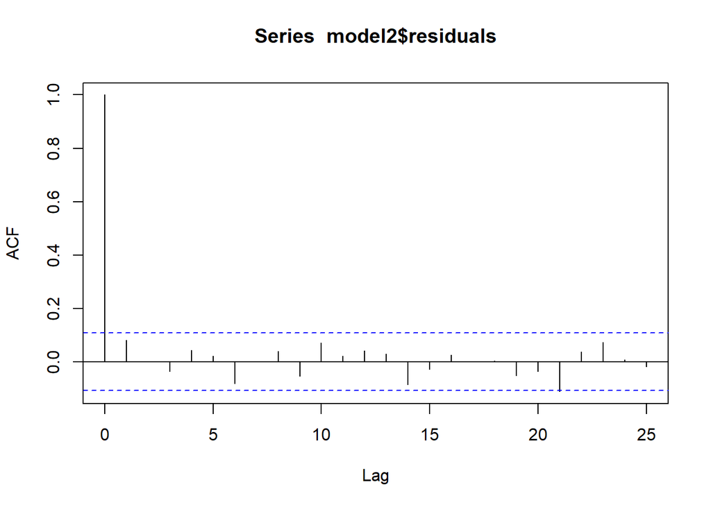

```r
# Plot checking for autocorreltaion of the residuals
acf(model2$residuals)
```

From the plot it is clear that there is no sign of autocorrelations in our data.

## Making Predictions

After reviewing all that the assumptions of linear regression are met, we can proceed to make predictions with our selected model. These predictions will be run on the Test partition of the Data.

```r
# Saves model predictions in variable predictions.
predictions <- predict(model2, testData)

# Creates data frame of actual values and predictions
actuals_preds <- data.frame(cbind(actuals=testData$house_price_of_unit_area, predicteds=predictions))
head(actuals_preds)
```

```
##    actuals predicteds
## 8     46.7  47.056803
## 9     18.8   7.965036
## 10    22.1  34.577233
## 18    37.4  37.363441
## 22    51.6  49.524372
## 24    47.9  47.678983
```

```r
# Check the correlation of the actual and predicteds as indication of how model performed.
cor_accuracy <- cor(actuals_preds)
cor_accuracy  # .72 Correlation
```

```
##              actuals predicteds
## actuals    1.0000000  0.8191499
## predicteds 0.8191499  1.0000000
```

Based off of the correlation between the actual values and the predicted values (.819), we can say that our model performed well. If the correlation was 1, the predictions would have been perfect.

To further check the model’s accuracy, I calculated the Min Max accuracy of the models.

```r
# Take Min Max accuracy to help judge model performance
min_max_accuracy <- mean(apply(actuals_preds, 1, min) / apply(actuals_preds, 1, max))
min_max_accuracy ## Min_Max Accuracy of 84% -- Not Bad!
```

```
## [1] 0.8411715
```

The Min Max Accuracy gives a value of 84%, which tells that the model is performing well. A perfect model would have a min max accuracy of 1.